# Risk Factor Analysis

## Outcome Variable

**Outcome Variable:** ever_swasted

## Predictor Variables

**Intervention Variable:** mwtkg

**Adjustment Set:**

unadjusted

## Stratifying Variables

The analysis was stratified on these variable(s):

- agecat
- studyid
- country

## Data Summary

| agecat | studyid | country | mwtkg | ever_swasted | n_cell | n |
| --- | --- | --- | --- | --- | --- | --- |
| 0-24 months | iLiNS-Zinc | BURKINA FASO | >=58 kg | 0 | 906 | 3217 |
| 0-24 months | iLiNS-Zinc | BURKINA FASO | >=58 kg | 1 | 31 | 3217 |
| 0-24 months | iLiNS-Zinc | BURKINA FASO | <52 kg | 0 | 1124 | 3217 |
| 0-24 months | iLiNS-Zinc | BURKINA FASO | <52 kg | 1 | 77 | 3217 |
| 0-24 months | iLiNS-Zinc | BURKINA FASO | [52-58) kg | 0 | 1033 | 3217 |
| 0-24 months | iLiNS-Zinc | BURKINA FASO | [52-58) kg | 1 | 46 | 3217 |
| 0-24 months | JiVitA-3 | BANGLADESH | >=58 kg | 0 | 634 | 26925 |
| 0-24 months | JiVitA-3 | BANGLADESH | >=58 kg | 1 | 27 | 26925 |
| 0-24 months | JiVitA-3 | BANGLADESH | <52 kg | 0 | 23001 | 26925 |
| 0-24 months | JiVitA-3 | BANGLADESH | <52 kg | 1 | 1505 | 26925 |
| 0-24 months | JiVitA-3 | BANGLADESH | [52-58) kg | 0 | 1645 | 26925 |
| 0-24 months | JiVitA-3 | BANGLADESH | [52-58) kg | 1 | 113 | 26925 |
| 0-24 months | LCNI-5 | MALAWI | >=58 kg | 0 | 113 | 838 |
| 0-24 months | LCNI-5 | MALAWI | >=58 kg | 1 | 1 | 838 |
| 0-24 months | LCNI-5 | MALAWI | <52 kg | 0 | 500 | 838 |
| 0-24 months | LCNI-5 | MALAWI | <52 kg | 1 | 4 | 838 |
| 0-24 months | LCNI-5 | MALAWI | [52-58) kg | 0 | 217 | 838 |
| 0-24 months | LCNI-5 | MALAWI | [52-58) kg | 1 | 3 | 838 |
| 0-24 months | MAL-ED | BANGLADESH | >=58 kg | 0 | 45 | 254 |
| 0-24 months | MAL-ED | BANGLADESH | >=58 kg | 1 | 3 | 254 |
| 0-24 months | MAL-ED | BANGLADESH | <52 kg | 0 | 144 | 254 |
| 0-24 months | MAL-ED | BANGLADESH | <52 kg | 1 | 18 | 254 |
| 0-24 months | MAL-ED | BANGLADESH | [52-58) kg | 0 | 44 | 254 |
| 0-24 months | MAL-ED | BANGLADESH | [52-58) kg | 1 | 0 | 254 |
| 0-24 months | MAL-ED | BRAZIL | >=58 kg | 0 | 140 | 221 |
| 0-24 months | MAL-ED | BRAZIL | >=58 kg | 1 | 3 | 221 |
| 0-24 months | MAL-ED | BRAZIL | <52 kg | 0 | 42 | 221 |
| 0-24 months | MAL-ED | BRAZIL | <52 kg | 1 | 0 | 221 |
| 0-24 months | MAL-ED | BRAZIL | [52-58) kg | 0 | 35 | 221 |
| 0-24 months | MAL-ED | BRAZIL | [52-58) kg | 1 | 1 | 221 |

[output cut: 270 more lines]

The following strata were considered:

- agecat: 0-24 months, studyid: iLiNS-Zinc, country: BURKINA FASO
- agecat: 0-24 months, studyid: JiVitA-3, country: BANGLADESH
- agecat: 0-24 months, studyid: LCNI-5, country: MALAWI
- agecat: 0-24 months, studyid: MAL-ED, country: BANGLADESH
- agecat: 0-24 months, studyid: MAL-ED, country: BRAZIL
- agecat: 0-24 months, studyid: MAL-ED, country: INDIA
- agecat: 0-24 months, studyid: MAL-ED, country: NEPAL
- agecat: 0-24 months, studyid: MAL-ED, country: PERU
- agecat: 0-24 months, studyid: MAL-ED, country: SOUTH AFRICA
- agecat: 0-24 months, studyid: MAL-ED, country: TANZANIA, UNITED REPUBLIC OF
- agecat: 0-24 months, studyid: NIH-Birth, country: BANGLADESH
- agecat: 0-24 months, studyid: NIH-Crypto, country: BANGLADESH
- agecat: 0-24 months, studyid: PROBIT, country: BELARUS
- agecat: 0-24 months, studyid: PROVIDE, country: BANGLADESH
- agecat: 0-24 months, studyid: SAS-CompFeed, country: INDIA
- agecat: 0-24 months, studyid: TanzaniaChild2, country: TANZANIA, UNITED REPUBLIC OF
- agecat: 0-24 months, studyid: ZVITAMBO, country: ZIMBABWE
- agecat: 0-6 months, studyid: JiVitA-3, country: BANGLADESH
- agecat: 0-6 months, studyid: LCNI-5, country: MALAWI
- agecat: 0-6 months, studyid: MAL-ED, country: BANGLADESH
- agecat: 0-6 months, studyid: MAL-ED, country: BRAZIL
- agecat: 0-6 months, studyid: MAL-ED, country: INDIA
- agecat: 0-6 months, studyid: MAL-ED, country: NEPAL
- agecat: 0-6 months, studyid: MAL-ED, country: PERU
- agecat: 0-6 months, studyid: MAL-ED, country: SOUTH AFRICA
- agecat: 0-6 months, studyid: MAL-ED, country: TANZANIA, UNITED REPUBLIC OF
- agecat: 0-6 months, studyid: NIH-Birth, country: BANGLADESH
- agecat: 0-6 months, studyid: NIH-Crypto, country: BANGLADESH
- agecat: 0-6 months, studyid: PROBIT, country: BELARUS
- agecat: 0-6 months, studyid: PROVIDE, country: BANGLADESH
- agecat: 0-6 months, studyid: SAS-CompFeed, country: INDIA
- agecat: 0-6 months, studyid: TanzaniaChild2, country: TANZANIA, UNITED REPUBLIC OF
- agecat: 0-6 months, studyid: ZVITAMBO, country: ZIMBABWE
- agecat: 6-24 months, studyid: iLiNS-Zinc, country: BURKINA FASO
- agecat: 6-24 months, studyid: JiVitA-3, country: BANGLADESH
- agecat: 6-24 months, studyid: LCNI-5, country: MALAWI
- agecat: 6-24 months, studyid: MAL-ED, country: BANGLADESH
- agecat: 6-24 months, studyid: MAL-ED, country: BRAZIL
- agecat: 6-24 months, studyid: MAL-ED, country: INDIA
- agecat: 6-24 months, studyid: MAL-ED, country: NEPAL
- agecat: 6-24 months, studyid: MAL-ED, country: PERU
- agecat: 6-24 months, studyid: MAL-ED, country: SOUTH AFRICA
- agecat: 6-24 months, studyid: MAL-ED, country: TANZANIA, UNITED REPUBLIC OF
- agecat: 6-24 months, studyid: NIH-Birth, country: BANGLADESH
- agecat: 6-24 months, studyid: NIH-Crypto, country: BANGLADESH
- agecat: 6-24 months, studyid: PROBIT, country: BELARUS
- agecat: 6-24 months, studyid: PROVIDE, country: BANGLADESH
- agecat: 6-24 months, studyid: SAS-CompFeed, country: INDIA
- agecat: 6-24 months, studyid: TanzaniaChild2, country: TANZANIA, UNITED REPUBLIC OF
- agecat: 6-24 months, studyid: ZVITAMBO, country: ZIMBABWE

### Dropped Strata

Some strata were dropped due to rare outcomes:

- agecat: 0-24 months, studyid: LCNI-5, country: MALAWI
- agecat: 0-24 months, studyid: MAL-ED, country: BANGLADESH
- agecat: 0-24 months, studyid: MAL-ED, country: BRAZIL
- agecat: 0-24 months, studyid: MAL-ED, country: INDIA
- agecat: 0-24 months, studyid: MAL-ED, country: NEPAL
- agecat: 0-24 months, studyid: MAL-ED, country: PERU
- agecat: 0-24 months, studyid: MAL-ED, country: SOUTH AFRICA
- agecat: 0-24 months, studyid: MAL-ED, country: TANZANIA, UNITED REPUBLIC OF
- agecat: 0-24 months, studyid: PROVIDE, country: BANGLADESH
- agecat: 0-6 months, studyid: LCNI-5, country: MALAWI
- agecat: 0-6 months, studyid: MAL-ED, country: BANGLADESH
- agecat: 0-6 months, studyid: MAL-ED, country: BRAZIL
- agecat: 0-6 months, studyid: MAL-ED, country: INDIA
- agecat: 0-6 months, studyid: MAL-ED, country: NEPAL
- agecat: 0-6 months, studyid: MAL-ED, country: PERU
- agecat: 0-6 months, studyid: MAL-ED, country: SOUTH AFRICA
- agecat: 0-6 months, studyid: MAL-ED, country: TANZANIA, UNITED REPUBLIC OF
- agecat: 0-6 months, studyid: NIH-Birth, country: BANGLADESH
- agecat: 0-6 months, studyid: PROVIDE, country: BANGLADESH
- agecat: 6-24 months, studyid: LCNI-5, country: MALAWI
- agecat: 6-24 months, studyid: MAL-ED, country: BANGLADESH
- agecat: 6-24 months, studyid: MAL-ED, country: BRAZIL
- agecat: 6-24 months, studyid: MAL-ED, country: INDIA
- agecat: 6-24 months, studyid: MAL-ED, country: NEPAL
- agecat: 6-24 months, studyid: MAL-ED, country: PERU
- agecat: 6-24 months, studyid: MAL-ED, country: SOUTH AFRICA
- agecat: 6-24 months, studyid: MAL-ED, country: TANZANIA, UNITED REPUBLIC OF
- agecat: 6-24 months, studyid: NIH-Birth, country: BANGLADESH
- agecat: 6-24 months, studyid: NIH-Crypto, country: BANGLADESH
- agecat: 6-24 months, studyid: PROBIT, country: BELARUS
- agecat: 6-24 months, studyid: PROVIDE, country: BANGLADESH

## Methods Detail

We’re interested in the causal parameters $E[Y_a]$ for all values of $a \in \mathcal{A}$. These parameters represent the mean outcome if, possibly contrary to fact, we intervened to set all units to have $A=a$. Under the randomization and positivity assumptions, these are identified by the statistical parameters $\psi_a=E_W[E_{Y|A,W}(Y|A=a,W)]$. In addition, we’re interested in the mean of $Y$, $E[Y]$ under no intervention (the observed mean). We will estimate these parameters by using SuperLearner to fit the relevant likelihood factors – $E_{Y|A,W}(Y|A=a,W)$ and $p(A=a|W)$, and then updating our likelihood fit using a joint TMLE.

For unadjusted analyses ($W=\{\}$), initial likelihoods were estimated using Lrnr_glm to estimate the simple $E(Y|A)$ and Lrnr_mean to estimate $p(A)$. For adjusted analyses, a small library containing Lrnr_glmnet, Lrnr_xgboost, and Lrnr_mean was used.

Having estimated these parameters, we will then use the delta method to estimate relative risks and attributable risks relative to a prespecified baseline level of $A$.

# Results Detail

## Results Plots

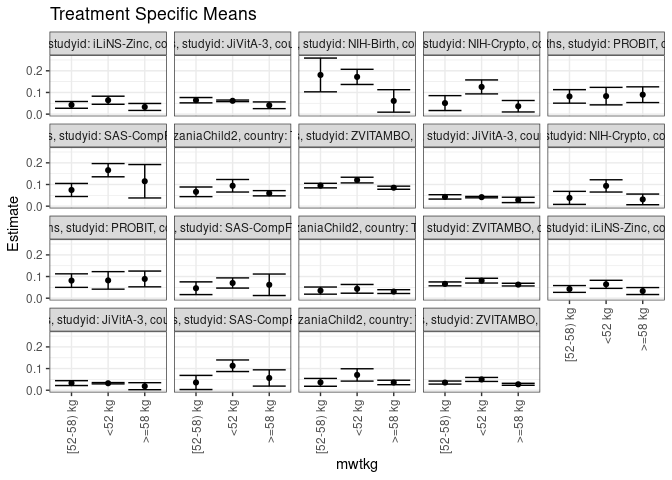

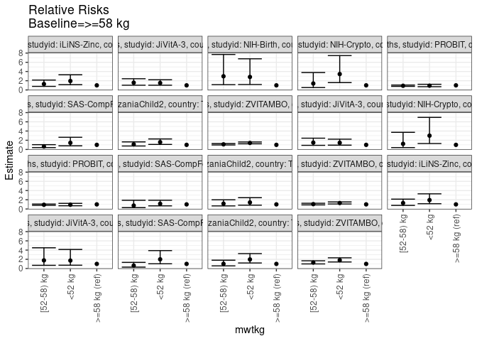

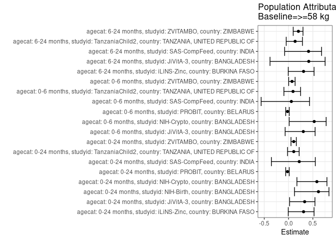

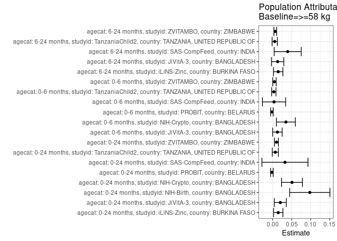

## Results Table

### Parameter: TSM

| agecat | studyid | country | intervention_level | baseline_level | estimate | ci_lower | ci_upper |
| --- | --- | --- | --- | --- | --- | --- | --- |
| 0-24 months | iLiNS-Zinc | BURKINA FASO | >=58 kg | NA | 0.0330843 | 0.0169986 | 0.0491700 |
| 0-24 months | iLiNS-Zinc | BURKINA FASO | <52 kg | NA | 0.0641132 | 0.0454946 | 0.0827319 |
| 0-24 months | iLiNS-Zinc | BURKINA FASO | [52-58) kg | NA | 0.0426321 | 0.0270024 | 0.0582617 |
| 0-24 months | JiVitA-3 | BANGLADESH | >=58 kg | NA | 0.0408472 | 0.0253769 | 0.0563175 |
| 0-24 months | JiVitA-3 | BANGLADESH | <52 kg | NA | 0.0614135 | 0.0576919 | 0.0651352 |
| 0-24 months | JiVitA-3 | BANGLADESH | [52-58) kg | NA | 0.0642776 | 0.0520051 | 0.0765500 |
| 0-24 months | NIH-Birth | BANGLADESH | >=58 kg | NA | 0.0609756 | 0.0091427 | 0.1128086 |
| 0-24 months | NIH-Birth | BANGLADESH | <52 kg | NA | 0.1718750 | 0.1369118 | 0.2068382 |
| 0-24 months | NIH-Birth | BANGLADESH | [52-58) kg | NA | 0.1808511 | 0.1029803 | 0.2587218 |
| 0-24 months | NIH-Crypto | BANGLADESH | >=58 kg | NA | 0.0364583 | 0.0099295 | 0.0629872 |
| 0-24 months | NIH-Crypto | BANGLADESH | <52 kg | NA | 0.1256158 | 0.0933571 | 0.1578744 |
| 0-24 months | NIH-Crypto | BANGLADESH | [52-58) kg | NA | 0.0509554 | 0.0165343 | 0.0853765 |
| 0-24 months | PROBIT | BELARUS | >=58 kg | NA | 0.0896974 | 0.0533235 | 0.1260714 |
| 0-24 months | PROBIT | BELARUS | <52 kg | NA | 0.0831123 | 0.0427146 | 0.1235100 |
| 0-24 months | PROBIT | BELARUS | [52-58) kg | NA | 0.0817104 | 0.0505324 | 0.1128884 |
| 0-24 months | SAS-CompFeed | INDIA | >=58 kg | NA | 0.1150442 | 0.0378916 | 0.1921969 |
| 0-24 months | SAS-CompFeed | INDIA | <52 kg | NA | 0.1660839 | 0.1355849 | 0.1965829 |
| 0-24 months | SAS-CompFeed | INDIA | [52-58) kg | NA | 0.0746888 | 0.0445568 | 0.1048208 |
| 0-24 months | TanzaniaChild2 | TANZANIA, UNITED REPUBLIC OF | >=58 kg | NA | 0.0596206 | 0.0475384 | 0.0717028 |
| 0-24 months | TanzaniaChild2 | TANZANIA, UNITED REPUBLIC OF | <52 kg | NA | 0.0941476 | 0.0652689 | 0.1230263 |
| 0-24 months | TanzaniaChild2 | TANZANIA, UNITED REPUBLIC OF | [52-58) kg | NA | 0.0662526 | 0.0440664 | 0.0884388 |
| 0-24 months | ZVITAMBO | ZIMBABWE | >=58 kg | NA | 0.0851941 | 0.0780227 | 0.0923654 |
| 0-24 months | ZVITAMBO | ZIMBABWE | <52 kg | NA | 0.1204669 | 0.1074408 | 0.1334929 |
| 0-24 months | ZVITAMBO | ZIMBABWE | [52-58) kg | NA | 0.0950119 | 0.0844245 | 0.1055992 |
| 0-6 months | JiVitA-3 | BANGLADESH | >=58 kg | NA | 0.0288316 | 0.0164414 | 0.0412217 |
| 0-6 months | JiVitA-3 | BANGLADESH | <52 kg | NA | 0.0416513 | 0.0384791 | 0.0448235 |
| 0-6 months | JiVitA-3 | BANGLADESH | [52-58) kg | NA | 0.0428082 | 0.0327502 | 0.0528662 |
| 0-6 months | NIH-Crypto | BANGLADESH | >=58 kg | NA | 0.0312500 | 0.0066227 | 0.0558773 |
| 0-6 months | NIH-Crypto | BANGLADESH | <52 kg | NA | 0.0935961 | 0.0652454 | 0.1219467 |
| 0-6 months | NIH-Crypto | BANGLADESH | [52-58) kg | NA | 0.0382166 | 0.0082076 | 0.0682255 |
| 0-6 months | PROBIT | BELARUS | >=58 kg | NA | 0.0889192 | 0.0525523 | 0.1252860 |
| 0-6 months | PROBIT | BELARUS | <52 kg | NA | 0.0822281 | 0.0417407 | 0.1227156 |
| 0-6 months | PROBIT | BELARUS | [52-58) kg | NA | 0.0812870 | 0.0500921 | 0.1124820 |
| 0-6 months | SAS-CompFeed | INDIA | >=58 kg | NA | 0.0619469 | 0.0123761 | 0.1115177 |
| 0-6 months | SAS-CompFeed | INDIA | <52 kg | NA | 0.0702371 | 0.0468032 | 0.0936709 |
| 0-6 months | SAS-CompFeed | INDIA | [52-58) kg | NA | 0.0460251 | 0.0166561 | 0.0753941 |
| 0-6 months | TanzaniaChild2 | TANZANIA, UNITED REPUBLIC OF | >=58 kg | NA | 0.0304878 | 0.0217150 | 0.0392606 |
| 0-6 months | TanzaniaChild2 | TANZANIA, UNITED REPUBLIC OF | <52 kg | NA | 0.0432570 | 0.0231397 | 0.0633743 |
| 0-6 months | TanzaniaChild2 | TANZANIA, UNITED REPUBLIC OF | [52-58) kg | NA | 0.0351967 | 0.0187591 | 0.0516342 |
| 0-6 months | ZVITAMBO | ZIMBABWE | >=58 kg | NA | 0.0627370 | 0.0564972 | 0.0689768 |
| 0-6 months | ZVITAMBO | ZIMBABWE | <52 kg | NA | 0.0810584 | 0.0700953 | 0.0920214 |
| 0-6 months | ZVITAMBO | ZIMBABWE | [52-58) kg | NA | 0.0660988 | 0.0571098 | 0.0750878 |
| 6-24 months | iLiNS-Zinc | BURKINA FASO | >=58 kg | NA | 0.0330843 | 0.0169986 | 0.0491700 |
| 6-24 months | iLiNS-Zinc | BURKINA FASO | <52 kg | NA | 0.0641132 | 0.0454946 | 0.0827319 |
| 6-24 months | iLiNS-Zinc | BURKINA FASO | [52-58) kg | NA | 0.0426321 | 0.0270024 | 0.0582617 |
| 6-24 months | JiVitA-3 | BANGLADESH | >=58 kg | NA | 0.0186916 | 0.0025656 | 0.0348176 |
| 6-24 months | JiVitA-3 | BANGLADESH | <52 kg | NA | 0.0322766 | 0.0292544 | 0.0352988 |
| 6-24 months | JiVitA-3 | BANGLADESH | [52-58) kg | NA | 0.0329670 | 0.0217078 | 0.0442263 |
| 6-24 months | SAS-CompFeed | INDIA | >=58 kg | NA | 0.0566038 | 0.0190352 | 0.0941723 |
| 6-24 months | SAS-CompFeed | INDIA | <52 kg | NA | 0.1130104 | 0.0863447 | 0.1396762 |
| 6-24 months | SAS-CompFeed | INDIA | [52-58) kg | NA | 0.0358744 | 0.0032414 | 0.0685075 |
| 6-24 months | TanzaniaChild2 | TANZANIA, UNITED REPUBLIC OF | >=58 kg | NA | 0.0358566 | 0.0255671 | 0.0461460 |
| 6-24 months | TanzaniaChild2 | TANZANIA, UNITED REPUBLIC OF | <52 kg | NA | 0.0707395 | 0.0422374 | 0.0992417 |
| 6-24 months | TanzaniaChild2 | TANZANIA, UNITED REPUBLIC OF | [52-58) kg | NA | 0.0364078 | 0.0183172 | 0.0544984 |
| 6-24 months | ZVITAMBO | ZIMBABWE | >=58 kg | NA | 0.0274846 | 0.0229622 | 0.0320070 |
| 6-24 months | ZVITAMBO | ZIMBABWE | <52 kg | NA | 0.0498354 | 0.0405873 | 0.0590836 |
| 6-24 months | ZVITAMBO | ZIMBABWE | [52-58) kg | NA | 0.0354391 | 0.0283266 | 0.0425517 |

### Parameter: E(Y)

| agecat | studyid | country | intervention_level | baseline_level | estimate | ci_lower | ci_upper |
| --- | --- | --- | --- | --- | --- | --- | --- |
| 0-24 months | iLiNS-Zinc | BURKINA FASO | NA | NA | 0.0478707 | 0.0359037 | 0.0598376 |
| 0-24 months | JiVitA-3 | BANGLADESH | NA | NA | 0.0610956 | 0.0576148 | 0.0645765 |
| 0-24 months | NIH-Birth | BANGLADESH | NA | NA | 0.1586538 | 0.1299648 | 0.1873429 |
| 0-24 months | NIH-Crypto | BANGLADESH | NA | NA | 0.0874172 | 0.0672569 | 0.1075775 |
| 0-24 months | PROBIT | BELARUS | NA | NA | 0.0877868 | 0.0528398 | 0.1227338 |
| 0-24 months | SAS-CompFeed | INDIA | NA | NA | 0.1475300 | 0.1183178 | 0.1767423 |
| 0-24 months | TanzaniaChild2 | TANZANIA, UNITED REPUBLIC OF | NA | NA | 0.0667517 | 0.0566626 | 0.0768408 |
| 0-24 months | ZVITAMBO | ZIMBABWE | NA | NA | 0.0953617 | 0.0899142 | 0.1008093 |
| 0-6 months | JiVitA-3 | BANGLADESH | NA | NA | 0.0414120 | 0.0384288 | 0.0443951 |
| 0-6 months | NIH-Crypto | BANGLADESH | NA | NA | 0.0662252 | 0.0484753 | 0.0839750 |
| 0-6 months | PROBIT | BELARUS | NA | NA | 0.0870607 | 0.0521007 | 0.1220207 |
| 0-6 months | SAS-CompFeed | INDIA | NA | NA | 0.0657277 | 0.0426068 | 0.0888486 |
| 0-6 months | TanzaniaChild2 | TANZANIA, UNITED REPUBLIC OF | NA | NA | 0.0335884 | 0.0263056 | 0.0408712 |
| 0-6 months | ZVITAMBO | ZIMBABWE | NA | NA | 0.0675481 | 0.0628829 | 0.0722134 |
| 6-24 months | iLiNS-Zinc | BURKINA FASO | NA | NA | 0.0478707 | 0.0359037 | 0.0598376 |
| 6-24 months | JiVitA-3 | BANGLADESH | NA | NA | 0.0319875 | 0.0290997 | 0.0348754 |
| 6-24 months | SAS-CompFeed | INDIA | NA | NA | 0.0962373 | 0.0722060 | 0.1202687 |
| 6-24 months | TanzaniaChild2 | TANZANIA, UNITED REPUBLIC OF | NA | NA | 0.0414560 | 0.0326689 | 0.0502431 |
| 6-24 months | ZVITAMBO | ZIMBABWE | NA | NA | 0.0344828 | 0.0308596 | 0.0381059 |

### Parameter: RR

| agecat | studyid | country | intervention_level | baseline_level | estimate | ci_lower | ci_upper |
| --- | --- | --- | --- | --- | --- | --- | --- |
| 0-24 months | iLiNS-Zinc | BURKINA FASO | >=58 kg | >=58 kg | 1.0000000 | 1.0000000 | 1.000000 |
| 0-24 months | iLiNS-Zinc | BURKINA FASO | <52 kg | >=58 kg | 1.9378744 | 1.1413669 | 3.290228 |
| 0-24 months | iLiNS-Zinc | BURKINA FASO | [52-58) kg | >=58 kg | 1.2885886 | 0.7760279 | 2.139692 |
| 0-24 months | JiVitA-3 | BANGLADESH | >=58 kg | >=58 kg | 1.0000000 | 1.0000000 | 1.000000 |
| 0-24 months | JiVitA-3 | BANGLADESH | <52 kg | >=58 kg | 1.5034942 | 1.0205527 | 2.214971 |
| 0-24 months | JiVitA-3 | BANGLADESH | [52-58) kg | >=58 kg | 1.5736106 | 1.0194017 | 2.429121 |
| 0-24 months | NIH-Birth | BANGLADESH | >=58 kg | >=58 kg | 1.0000000 | 1.0000000 | 1.000000 |
| 0-24 months | NIH-Birth | BANGLADESH | <52 kg | >=58 kg | 2.8187500 | 1.1761332 | 6.755486 |
| 0-24 months | NIH-Birth | BANGLADESH | [52-58) kg | >=58 kg | 2.9659574 | 1.1437460 | 7.691309 |
| 0-24 months | NIH-Crypto | BANGLADESH | >=58 kg | >=58 kg | 1.0000000 | 1.0000000 | 1.000000 |
| 0-24 months | NIH-Crypto | BANGLADESH | <52 kg | >=58 kg | 3.4454609 | 1.5926859 | 7.453573 |
| 0-24 months | NIH-Crypto | BANGLADESH | [52-58) kg | >=58 kg | 1.3976342 | 0.5178396 | 3.772175 |
| 0-24 months | PROBIT | BELARUS | >=58 kg | >=58 kg | 1.0000000 | 1.0000000 | 1.000000 |
| 0-24 months | PROBIT | BELARUS | <52 kg | >=58 kg | 0.9265848 | 0.7008582 | 1.225012 |
| 0-24 months | PROBIT | BELARUS | [52-58) kg | >=58 kg | 0.9109559 | 0.7797067 | 1.064299 |
| 0-24 months | SAS-CompFeed | INDIA | >=58 kg | >=58 kg | 1.0000000 | 1.0000000 | 1.000000 |
| 0-24 months | SAS-CompFeed | INDIA | <52 kg | >=58 kg | 1.4436525 | 0.7889414 | 2.641682 |
| 0-24 months | SAS-CompFeed | INDIA | [52-58) kg | >=58 kg | 0.6492180 | 0.4035738 | 1.044379 |
| 0-24 months | TanzaniaChild2 | TANZANIA, UNITED REPUBLIC OF | >=58 kg | >=58 kg | 1.0000000 | 1.0000000 | 1.000000 |
| 0-24 months | TanzaniaChild2 | TANZANIA, UNITED REPUBLIC OF | <52 kg | >=58 kg | 1.5791117 | 1.0933282 | 2.280737 |
| 0-24 months | TanzaniaChild2 | TANZANIA, UNITED REPUBLIC OF | [52-58) kg | >=58 kg | 1.1112366 | 0.7513046 | 1.643603 |
| 0-24 months | ZVITAMBO | ZIMBABWE | >=58 kg | >=58 kg | 1.0000000 | 1.0000000 | 1.000000 |
| 0-24 months | ZVITAMBO | ZIMBABWE | <52 kg | >=58 kg | 1.4140284 | 1.2329514 | 1.621699 |
| 0-24 months | ZVITAMBO | ZIMBABWE | [52-58) kg | >=58 kg | 1.1152402 | 0.9698804 | 1.282386 |
| 0-6 months | JiVitA-3 | BANGLADESH | >=58 kg | >=58 kg | 1.0000000 | 1.0000000 | 1.000000 |
| 0-6 months | JiVitA-3 | BANGLADESH | <52 kg | >=58 kg | 1.4446428 | 0.9332466 | 2.236271 |
| 0-6 months | JiVitA-3 | BANGLADESH | [52-58) kg | >=58 kg | 1.4847693 | 0.8989688 | 2.452298 |
| 0-6 months | NIH-Crypto | BANGLADESH | >=58 kg | >=58 kg | 1.0000000 | 1.0000000 | 1.000000 |
| 0-6 months | NIH-Crypto | BANGLADESH | <52 kg | >=58 kg | 2.9950739 | 1.2874825 | 6.967448 |
| 0-6 months | NIH-Crypto | BANGLADESH | [52-58) kg | >=58 kg | 1.2229299 | 0.4020223 | 3.720086 |
| 0-6 months | PROBIT | BELARUS | >=58 kg | >=58 kg | 1.0000000 | 1.0000000 | 1.000000 |
| 0-6 months | PROBIT | BELARUS | <52 kg | >=58 kg | 0.9247514 | 0.6984485 | 1.224378 |
| 0-6 months | PROBIT | BELARUS | [52-58) kg | >=58 kg | 0.9141680 | 0.7816080 | 1.069210 |
| 0-6 months | SAS-CompFeed | INDIA | >=58 kg | >=58 kg | 1.0000000 | 1.0000000 | 1.000000 |
| 0-6 months | SAS-CompFeed | INDIA | <52 kg | >=58 kg | 1.1338267 | 0.6789947 | 1.893333 |
| 0-6 months | SAS-CompFeed | INDIA | [52-58) kg | >=58 kg | 0.7429767 | 0.2925146 | 1.887134 |
| 0-6 months | TanzaniaChild2 | TANZANIA, UNITED REPUBLIC OF | >=58 kg | >=58 kg | 1.0000000 | 1.0000000 | 1.000000 |
| 0-6 months | TanzaniaChild2 | TANZANIA, UNITED REPUBLIC OF | <52 kg | >=58 kg | 1.4188295 | 0.8211469 | 2.451543 |
| 0-6 months | TanzaniaChild2 | TANZANIA, UNITED REPUBLIC OF | [52-58) kg | >=58 kg | 1.1544513 | 0.6670277 | 1.998055 |
| 0-6 months | ZVITAMBO | ZIMBABWE | >=58 kg | >=58 kg | 1.0000000 | 1.0000000 | 1.000000 |
| 0-6 months | ZVITAMBO | ZIMBABWE | <52 kg | >=58 kg | 1.2920349 | 1.0923553 | 1.528215 |
| 0-6 months | ZVITAMBO | ZIMBABWE | [52-58) kg | >=58 kg | 1.0535859 | 0.8902231 | 1.246927 |
| 6-24 months | iLiNS-Zinc | BURKINA FASO | >=58 kg | >=58 kg | 1.0000000 | 1.0000000 | 1.000000 |
| 6-24 months | iLiNS-Zinc | BURKINA FASO | <52 kg | >=58 kg | 1.9378744 | 1.1413669 | 3.290228 |
| 6-24 months | iLiNS-Zinc | BURKINA FASO | [52-58) kg | >=58 kg | 1.2885886 | 0.7760279 | 2.139692 |
| 6-24 months | JiVitA-3 | BANGLADESH | >=58 kg | >=58 kg | 1.0000000 | 1.0000000 | 1.000000 |
| 6-24 months | JiVitA-3 | BANGLADESH | <52 kg | >=58 kg | 1.7267972 | 0.7211387 | 4.134889 |
| 6-24 months | JiVitA-3 | BANGLADESH | [52-58) kg | >=58 kg | 1.7637363 | 0.6919969 | 4.495346 |
| 6-24 months | SAS-CompFeed | INDIA | >=58 kg | >=58 kg | 1.0000000 | 1.0000000 | 1.000000 |
| 6-24 months | SAS-CompFeed | INDIA | <52 kg | >=58 kg | 1.9965179 | 1.0255200 | 3.886890 |
| 6-24 months | SAS-CompFeed | INDIA | [52-58) kg | >=58 kg | 0.6337818 | 0.3023311 | 1.328607 |
| 6-24 months | TanzaniaChild2 | TANZANIA, UNITED REPUBLIC OF | >=58 kg | >=58 kg | 1.0000000 | 1.0000000 | 1.000000 |
| 6-24 months | TanzaniaChild2 | TANZANIA, UNITED REPUBLIC OF | <52 kg | >=58 kg | 1.9728474 | 1.2029996 | 3.235352 |
| 6-24 months | TanzaniaChild2 | TANZANIA, UNITED REPUBLIC OF | [52-58) kg | >=58 kg | 1.0153722 | 0.5720418 | 1.802282 |
| 6-24 months | ZVITAMBO | ZIMBABWE | >=58 kg | >=58 kg | 1.0000000 | 1.0000000 | 1.000000 |
| 6-24 months | ZVITAMBO | ZIMBABWE | <52 kg | >=58 kg | 1.8132159 | 1.4149381 | 2.323601 |
| 6-24 months | ZVITAMBO | ZIMBABWE | [52-58) kg | >=58 kg | 1.2894196 | 0.9946805 | 1.671495 |

### Parameter: PAR

| agecat | studyid | country | intervention_level | baseline_level | estimate | ci_lower | ci_upper |
| --- | --- | --- | --- | --- | --- | --- | --- |
| 0-24 months | iLiNS-Zinc | BURKINA FASO | >=58 kg | NA | 0.0147864 | 0.0024543 | 0.0271184 |
| 0-24 months | JiVitA-3 | BANGLADESH | >=58 kg | NA | 0.0202484 | 0.0045086 | 0.0359882 |
| 0-24 months | NIH-Birth | BANGLADESH | >=58 kg | NA | 0.0976782 | 0.0447291 | 0.1506274 |
| 0-24 months | NIH-Crypto | BANGLADESH | >=58 kg | NA | 0.0509589 | 0.0235314 | 0.0783864 |
| 0-24 months | PROBIT | BELARUS | >=58 kg | NA | -0.0019106 | -0.0053134 | 0.0014921 |
| 0-24 months | SAS-CompFeed | INDIA | >=58 kg | NA | 0.0324858 | -0.0280393 | 0.0930109 |
| 0-24 months | TanzaniaChild2 | TANZANIA, UNITED REPUBLIC OF | >=58 kg | NA | 0.0071311 | -0.0009032 | 0.0151654 |
| 0-24 months | ZVITAMBO | ZIMBABWE | >=58 kg | NA | 0.0101677 | 0.0049251 | 0.0154102 |
| 0-6 months | JiVitA-3 | BANGLADESH | >=58 kg | NA | 0.0125804 | 0.0000852 | 0.0250756 |
| 0-6 months | NIH-Crypto | BANGLADESH | >=58 kg | NA | 0.0349752 | 0.0102146 | 0.0597358 |
| 0-6 months | PROBIT | BELARUS | >=58 kg | NA | -0.0018585 | -0.0052447 | 0.0015278 |
| 0-6 months | SAS-CompFeed | INDIA | >=58 kg | NA | 0.0037808 | -0.0266346 | 0.0341961 |
| 0-6 months | TanzaniaChild2 | TANZANIA, UNITED REPUBLIC OF | >=58 kg | NA | 0.0031006 | -0.0026792 | 0.0088804 |
| 0-6 months | ZVITAMBO | ZIMBABWE | >=58 kg | NA | 0.0048111 | 0.0003320 | 0.0092903 |
| 6-24 months | iLiNS-Zinc | BURKINA FASO | >=58 kg | NA | 0.0147864 | 0.0024543 | 0.0271184 |
| 6-24 months | JiVitA-3 | BANGLADESH | >=58 kg | NA | 0.0132959 | -0.0028644 | 0.0294562 |
| 6-24 months | SAS-CompFeed | INDIA | >=58 kg | NA | 0.0396336 | 0.0041026 | 0.0751645 |
| 6-24 months | TanzaniaChild2 | TANZANIA, UNITED REPUBLIC OF | >=58 kg | NA | 0.0055994 | -0.0013818 | 0.0125807 |
| 6-24 months | ZVITAMBO | ZIMBABWE | >=58 kg | NA | 0.0069982 | 0.0034624 | 0.0105339 |

### Parameter: PAF

| agecat | studyid | country | intervention_level | baseline_level | estimate | ci_lower | ci_upper |
| --- | --- | --- | --- | --- | --- | --- | --- |
| 0-24 months | iLiNS-Zinc | BURKINA FASO | >=58 kg | NA | 0.3088816 | -0.0062239 | 0.5253098 |
| 0-24 months | JiVitA-3 | BANGLADESH | >=58 kg | NA | 0.3314219 | 0.0213176 | 0.5432669 |
| 0-24 months | NIH-Birth | BANGLADESH | >=58 kg | NA | 0.6156689 | 0.1221060 | 0.8317446 |
| 0-24 months | NIH-Crypto | BANGLADESH | >=58 kg | NA | 0.5829388 | 0.1719680 | 0.7899356 |
| 0-24 months | PROBIT | BELARUS | >=58 kg | NA | -0.0217644 | -0.0587899 | 0.0139663 |
| 0-24 months | SAS-CompFeed | INDIA | >=58 kg | NA | 0.2201978 | -0.3531912 | 0.5506241 |
| 0-24 months | TanzaniaChild2 | TANZANIA, UNITED REPUBLIC OF | >=58 kg | NA | 0.1068303 | -0.0209323 | 0.2186043 |
| 0-24 months | ZVITAMBO | ZIMBABWE | >=58 kg | NA | 0.1066220 | 0.0502118 | 0.1596818 |
| 0-6 months | JiVitA-3 | BANGLADESH | >=58 kg | NA | 0.3037865 | -0.0698920 | 0.5469513 |
| 0-6 months | NIH-Crypto | BANGLADESH | >=58 kg | NA | 0.5281250 | 0.0134939 | 0.7742883 |
| 0-6 months | PROBIT | BELARUS | >=58 kg | NA | -0.0213466 | -0.0585598 | 0.0145583 |
| 0-6 months | SAS-CompFeed | INDIA | >=58 kg | NA | 0.0575221 | -0.5639304 | 0.4320306 |
| 0-6 months | TanzaniaChild2 | TANZANIA, UNITED REPUBLIC OF | >=58 kg | NA | 0.0923124 | -0.0958350 | 0.2481562 |
| 0-6 months | ZVITAMBO | ZIMBABWE | >=58 kg | NA | 0.0712253 | 0.0026605 | 0.1350763 |
| 6-24 months | iLiNS-Zinc | BURKINA FASO | >=58 kg | NA | 0.3088816 | -0.0062239 | 0.5253098 |
| 6-24 months | JiVitA-3 | BANGLADESH | >=58 kg | NA | 0.4156597 | -0.3815110 | 0.7528405 |
| 6-24 months | SAS-CompFeed | INDIA | >=58 kg | NA | 0.4118315 | -0.0801834 | 0.6797375 |
| 6-24 months | TanzaniaChild2 | TANZANIA, UNITED REPUBLIC OF | >=58 kg | NA | 0.1350695 | -0.0480923 | 0.2862224 |
| 6-24 months | ZVITAMBO | ZIMBABWE | >=58 kg | NA | 0.2029476 | 0.0959230 | 0.2973026 |